# Vessel activity in the Northeast Pacific

- Show All Code
- Hide All Code
- View Source

The 2025 AIS cost layer for the Cobb-Eickelberg seamount chain prioritization: kilowatt-hours of fishing and other vessel activity, with trends from 2015 to 2026

Author

Affiliation

Gavin McDonald

Environmental Markets Lab (emLab), University of California, Santa Barbara

Published

October 16, 2026

**NoteA first look**

This is a first look at the AIS data for our project, [New Wave of High Seas Protections](https://bren.ucsb.edu/projects/new-wave-high-seas-protections-scoping-northern-seamount-ecosystems-under-biodiversity). A few numbers may still shift as we go, so let’s keep these within the team for now rather than citing or sharing them.

**Setup: data, colours and helpers**

```r
# Everything here is read from small files committed to ../data by the targets
# pipeline, so this page renders without BigQuery access.

# Pixel size of the site's data (degrees). It matches the project's other
# cost layers, and the file names in ../data.
pixel_size <- 0.05
data_dir <- "../data"
repo_url <- "https://github.com/emlab-ucsb/mesm-gp-ne-pacific-high-seas-mpa"
bq_table <- "emlab-gcp.mesm_gp_ne_pacific_high_seas.ais_effort_by_pixel_v20261016"

cost_layer <- readr::read_csv(
  file.path(data_dir, "ais_effort_by_pixel_0p05deg_2025.csv.gz"),
  show_col_types = FALSE
)
all_years <- readr::read_csv(
  file.path(data_dir, "ais_effort_by_pixel_0p05deg_all_years.csv.gz"),
  show_col_types = FALSE
)
fishing_yearly <- readr::read_csv(
  file.path(data_dir, "ais_fishing_activity_by_pixel_0p05deg_yearly.csv.gz"),
  show_col_types = FALSE
)
monthly <- readr::read_csv(file.path(data_dir, "ais_effort_by_pixel_summary.csv"), show_col_types = FALSE)
vessel_classes <- readr::read_csv(file.path(data_dir, "ais_vessel_class_summary.csv"), show_col_types = FALSE)
download_sizes <- readr::read_csv(file.path(data_dir, "ais_effort_by_pixel_download_sizes.csv"), show_col_types = FALSE)
land <- sf::st_read(file.path(data_dir, "land_ne_50m.geojson"), quiet = TRUE)
study_area <- sf::st_read(file.path(data_dir, "small_gfw_bbox_mesm", "gfwbbox_sm.shp"), quiet = TRUE)

# The extent of the data: the study area box pushed out to whole degrees
map_limits <- list(lon = c(-160, -120), lat = c(39, 62))

# Activity groups: fishing activity, and non-fishing activity split into the
# two big users of the area and everything else (tugs, patrol and research
# vessels, fishing vessels when they aren't fishing, ...)
group_levels <- c("Fishing activity", "Cargo and tankers", "Passenger", "Other non-fishing")
activity_group <- function(vessel_class, fishing_activity) {
  group <- dplyr::case_when(
    fishing_activity ~ group_levels[1],
    grepl("cargo|tanker|reefer|bunker", vessel_class) ~ group_levels[2],
    vessel_class == "passenger" ~ group_levels[3],
    TRUE ~ group_levels[4]
  )
  factor(group, levels = group_levels)
}

# Colours: text and chart chrome, and viridis for everything that carries data
ink <- list(
  primary = "#0b0b0b",
  secondary = "#52514e",
  muted = "#898781",
  grid = "#e1e0d9",
  surface = "#fcfcfb"
)
land_fill <- "#e1e0d9"
data_colour <- viridisLite::viridis(1, begin = 0.4, end = 0.4)

theme_site <- function() {
  ggplot2::theme_minimal(base_size = 11) +
    ggplot2::theme(
      plot.background = ggplot2::element_rect(fill = ink$surface, colour = NA),
      panel.background = ggplot2::element_rect(fill = ink$surface, colour = NA),
      panel.grid.major = ggplot2::element_line(colour = ink$grid, linewidth = 0.25),
      panel.grid.minor = ggplot2::element_blank(),
      text = ggplot2::element_text(colour = ink$secondary),
      axis.text = ggplot2::element_text(colour = ink$muted),
      plot.title = ggplot2::element_text(colour = ink$primary, face = "bold"),
      strip.text = ggplot2::element_text(colour = ink$primary, face = "bold", hjust = 0),
      legend.position = "top",
      legend.justification = "left"
    )
}

theme_map <- function() {
  theme_site() +
    ggplot2::theme(
      panel.grid.major = ggplot2::element_blank(),
      axis.title = ggplot2::element_blank()
    )
}

# Short-scale labels: 300M, 1.2B
short_number <- scales::label_number(
  accuracy = 0.1,
  scale_cut = scales::cut_short_scale(),
  drop0trailing = TRUE
)

# kW-hours per pixel on a log scale. Vessel activity spans about nine orders
# of magnitude, from a few minutes in empty ocean to years of engine time in
# port, so the colours run from the 5th to the 99th percentile of pixels
# (rounded out to powers of ten) and anything beyond takes the end colour; the
# legend marks the two ends with <= and >=.
colour_limits <- function(values) {
  10^c(
    floor(log10(stats::quantile(values, 0.05))),
    ceiling(log10(stats::quantile(values, 0.99)))
  )
}

log_labels <- function(breaks) {
  labels <- vapply(
    breaks,
    function(b) {
      if (b >= 1000) {
        scales::label_number(accuracy = 1, scale_cut = scales::cut_short_scale())(b)
      } else {
        format(b, scientific = FALSE, drop0trailing = TRUE, trim = TRUE)
      }
    },
    character(1)
  )
  labels[1] <- paste("≤", labels[1])
  labels[length(labels)] <- paste("≥", labels[length(labels)])
  labels
}

fill_kw_hours <- function(name, limits) {
  ggplot2::scale_fill_viridis_c(
    option = "viridis",
    trans = "log10",
    limits = limits,
    breaks = 10^seq(log10(limits[1]), log10(limits[2])),
    labels = log_labels,
    oob = scales::squish,
    name = name,
    guide = ggplot2::guide_colourbar(
      title.position = "top",
      barwidth = ggplot2::unit(16, "lines"),
      barheight = ggplot2::unit(0.5, "lines")
    )
  )
}

# Map one value per pixel (`kw_hours`)
map_pixels <- function(pixels, fill_name) {
  ggplot2::ggplot() +
    ggplot2::geom_tile(
      data = pixels,
      ggplot2::aes(x = lon_center, y = lat_center, fill = kw_hours),
      width = pixel_size,
      height = pixel_size
    ) +
    ggplot2::geom_sf(data = land, fill = land_fill, colour = NA) +
    ggplot2::geom_sf(data = study_area, fill = NA, colour = ink$secondary, linewidth = 0.3) +
    fill_kw_hours(fill_name, limits = colour_limits(pixels$kw_hours)) +
    ggplot2::coord_sf(xlim = map_limits$lon, ylim = map_limits$lat, expand = FALSE) +
    theme_map()
}

# "drifting_longlines" -> "Drifting longlines", with the catch-all classes
# spelled out
pretty_class <- function(x) {
  catch_alls <- c(
    fishing = "Fishing (gear unknown)",
    non_fishing = "Non-fishing (type unknown)",
    other_not_fishing = "Other non-fishing",
    dredge_non_fishing = "Dredge (non-fishing)"
  )
  pretty <- gsub("_", " ", x)
  pretty <- paste0(toupper(substr(pretty, 1, 1)), substr(pretty, 2, nchar(pretty)))
  dplyr::if_else(x %in% names(catch_alls), unname(catch_alls[x]), pretty)
}

millions <- function(x) scales::label_number(accuracy = 0.1, scale = 1e-6, suffix = " million")(x)
billions <- function(x) scales::label_number(accuracy = 1, scale = 1e-9, suffix = " billion")(x)
percent <- function(x, accuracy = 1) scales::label_percent(accuracy = accuracy)(x)

# Headline numbers: the whole record for hours, and the 2025 cost layer
# (which every map and bar chart shows) for kW-hours
total_hours <- sum(all_years$hours)
cost_layer_year <- unique(cost_layer$year)
total_kw_hours <- sum(cost_layer$kw_hours)
fishing_kw_hours <- sum(cost_layer$kw_hours[cost_layer$fishing_activity])
first_month <- format(min(monthly$month), "%B %Y")
last_month <- format(max(monthly$month), "%B %Y")
```

This page walks through the vessel activity data I put together for our cost layer. It’s built from [Global Fishing Watch](https://globalfishingwatch.org) (GFW) AIS data for every vessel GFW could reliably identify, from January 2015 to August 2026. AIS is the tracking system ships use to broadcast their position, and GFW turns those positions into hours of activity, along with a model estimate of when fishing vessels are actually fishing. All told, that’s 278.5 million hours of vessel activity in our area.

The maps and bar charts below all show **2025, our main cost layer**. The full record from 2015 is there for the trends at the end of this section.

I’ve shown everything here in **kilowatt-hours**: hours weighted by each vessel’s engine power, which is GFW’s standard measure of effort. In 2025 that’s 97 billion kW-hours in total, and only 0.11% of them are fishing activity. Cargo ships and tankers have engines many times bigger than most fishing vessels, so non-fishing activity comes out about 900 times larger than fishing activity in kW-hours. That’s why fishing and non-fishing each get their own maps and panels below, with their own scales.

The maps use 0.05° pixels, and the outline is our study area box. The colours are on a log scale and capped at both ends (that’s what the ≤ and ≥ on the legends mean), so you can see both the quiet open ocean and the busiest areas. If you’d like to jump straight to the data, head to Working with the data.

# What the data show

## Fishing activity

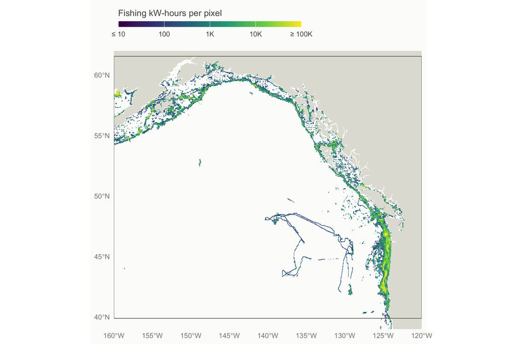

Kilowatt-hours of fishing activity in 2025: fishing vessels at positions GFW’s model scores as fishing.

```r
fishing <- cost_layer |>
  dplyr::filter(fishing_activity) |>
  dplyr::group_by(lon_center, lat_center) |>
  dplyr::summarise(kw_hours = sum(kw_hours), .groups = "drop")

map_pixels(fishing, "Fishing kW-hours per pixel")
```

## Non-fishing activity

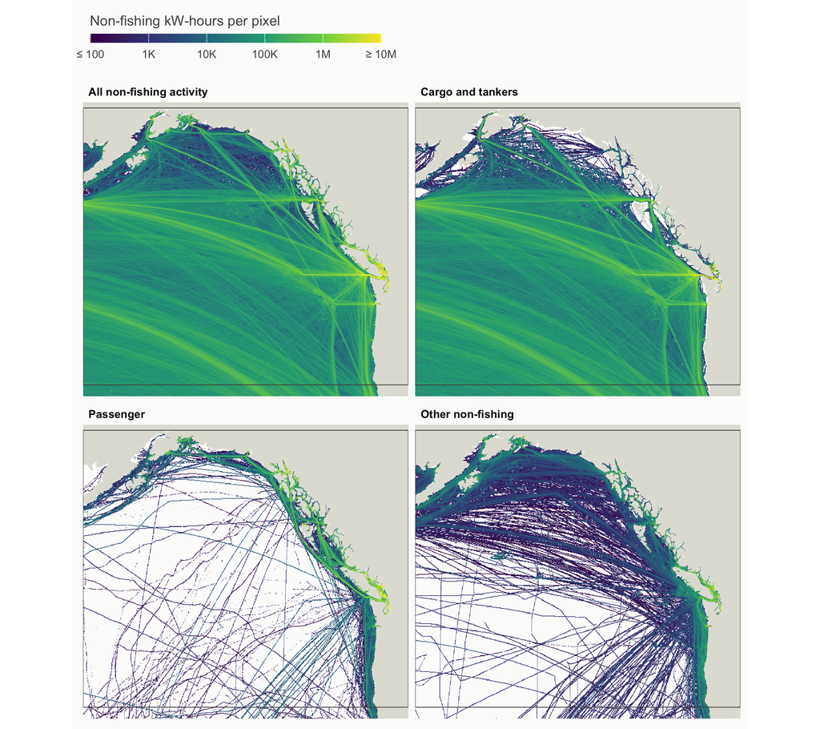

Kilowatt-hours of non-fishing activity in 2025, all on one colour scale. Other non-fishing includes tugs, patrol and research vessels, and fishing vessels when they aren’t fishing.

```r
non_fishing <- cost_layer |>
  dplyr::filter(!fishing_activity) |>
  dplyr::mutate(group = activity_group(vessel_class, fishing_activity))

non_fishing_panels <- dplyr::bind_rows(
  non_fishing |>
    dplyr::group_by(lon_center, lat_center) |>
    dplyr::summarise(kw_hours = sum(kw_hours), .groups = "drop") |>
    dplyr::mutate(panel = "All non-fishing activity"),
  non_fishing |>
    dplyr::group_by(panel = as.character(group), lon_center, lat_center) |>
    dplyr::summarise(kw_hours = sum(kw_hours), .groups = "drop")
) |>
  dplyr::mutate(panel = factor(panel, levels = c("All non-fishing activity", group_levels[-1])))

map_pixels(non_fishing_panels, "Non-fishing kW-hours per pixel") +
  ggplot2::facet_wrap(ggplot2::vars(panel), ncol = 2) +
  ggplot2::theme(axis.text = ggplot2::element_blank())
```

## By vessel type

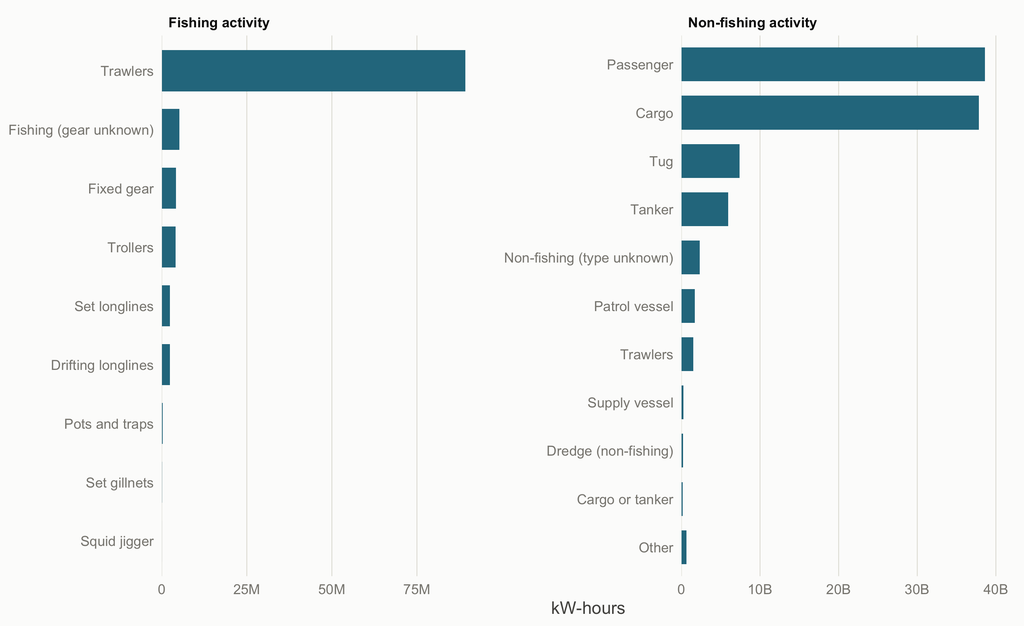

Kilowatt-hours by vessel type in 2025. The two panels have different scales. Non-fishing activity includes fishing vessels’ time when they aren’t fishing. Classes outside the top ten in a panel are grouped as Other.

```r
top_n_classes <- 10
activity_levels <- c("Fishing activity", "Non-fishing activity")

by_class <- cost_layer |>
  dplyr::mutate(
    activity = factor(
      dplyr::if_else(fishing_activity, activity_levels[1], activity_levels[2]),
      levels = activity_levels
    )
  ) |>
  dplyr::group_by(activity, vessel_class) |>
  dplyr::summarise(kw_hours = sum(kw_hours), .groups = "drop") |>
  dplyr::group_by(activity) |>
  dplyr::mutate(
    vessel_type = dplyr::if_else(
      dplyr::min_rank(dplyr::desc(kw_hours)) <= top_n_classes,
      pretty_class(vessel_class),
      "Other"
    )
  ) |>
  dplyr::group_by(activity, vessel_type) |>
  dplyr::summarise(kw_hours = sum(kw_hours), .groups = "drop") |>
  # Order bars within each panel, largest at the top and Other at the bottom
  dplyr::mutate(
    sort_value = dplyr::if_else(vessel_type == "Other", -Inf, kw_hours),
    bar = paste(activity, vessel_type, sep = "___")
  ) |>
  dplyr::arrange(activity, sort_value) |>
  dplyr::mutate(bar = factor(bar, levels = unique(bar)))

ggplot2::ggplot(by_class, ggplot2::aes(x = kw_hours, y = bar)) +
  ggplot2::geom_col(fill = data_colour, width = 0.7) +
  ggplot2::facet_wrap(ggplot2::vars(activity), scales = "free", ncol = 2) +
  ggplot2::scale_y_discrete(labels = function(x) sub("^.*___", "", x)) +
  ggplot2::scale_x_continuous(
    labels = short_number,
    breaks = scales::breaks_extended(n = 5),
    expand = ggplot2::expansion(mult = c(0, 0.1))
  ) +
  ggplot2::labs(x = "kW-hours", y = NULL) +
  theme_site() +
  ggplot2::theme(panel.grid.major.y = ggplot2::element_blank())
```

## Over time

These use the full record, January 2015 to August 2026.

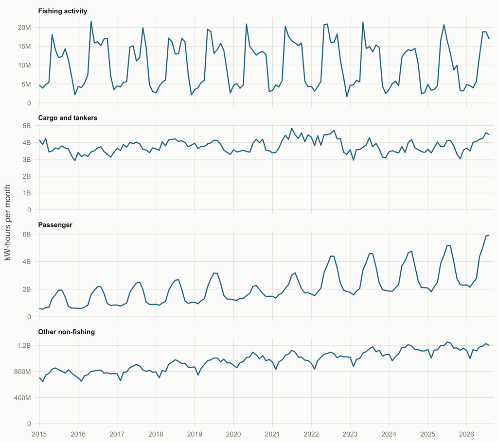

Kilowatt-hours per month. Each panel has its own scale.

```r
monthly_groups <- monthly |>
  dplyr::mutate(group = activity_group(vessel_class, fishing_activity)) |>
  dplyr::group_by(month, group) |>
  dplyr::summarise(kw_hours = sum(kw_hours), .groups = "drop")

ggplot2::ggplot(monthly_groups, ggplot2::aes(x = month, y = kw_hours)) +
  ggplot2::geom_line(colour = data_colour, linewidth = 0.7) +
  ggplot2::facet_wrap(ggplot2::vars(group), scales = "free_y", ncol = 1) +
  ggplot2::scale_x_date(
    date_breaks = "1 year",
    date_labels = "%Y",
    expand = ggplot2::expansion(mult = c(0.01, 0.01))
  ) +
  ggplot2::scale_y_continuous(labels = short_number, limits = c(0, NA)) +
  ggplot2::labs(x = NULL, y = "kW-hours per month") +
  theme_site()
```

One heads-up when reading these lines: they reflect both real changes in activity and changes in how well AIS gets picked up. Satellite AIS reception has improved a lot since 2015, so some of any increase is better coverage rather than more vessels.

Here’s where fishing happened each year:

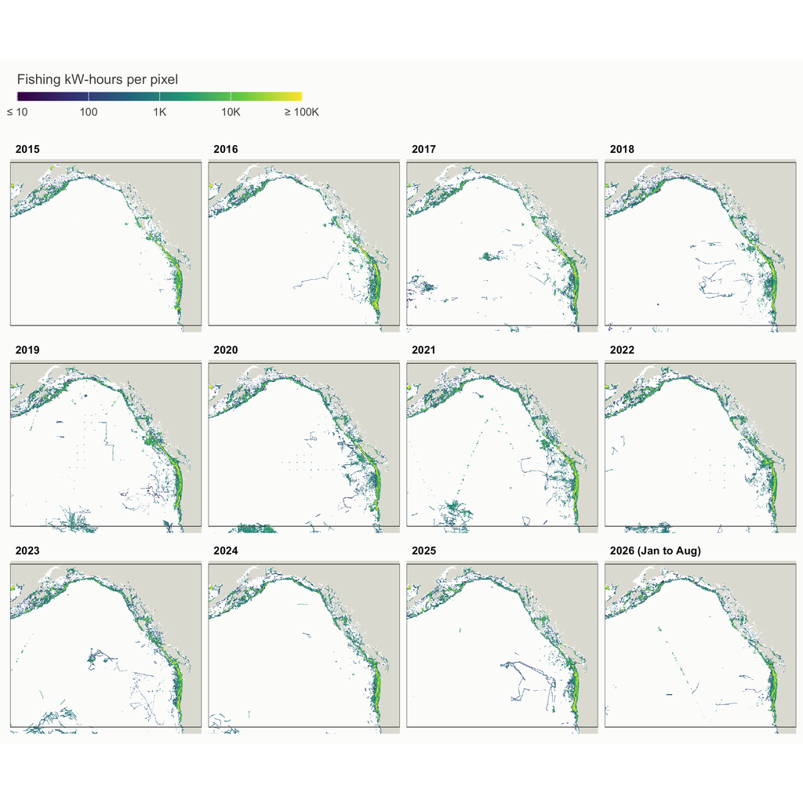

Where fishing happened each year, in kilowatt-hours of fishing activity. 2026 covers January to August only.

```r
fishing_by_year <- fishing_yearly |>
  dplyr::group_by(year, lon_center, lat_center) |>
  dplyr::summarise(kw_hours = sum(kw_hours), .groups = "drop") |>
  dplyr::mutate(
    year_label = dplyr::if_else(year == max(year), paste(year, "(Jan to Aug)"), as.character(year))
  )

map_pixels(fishing_by_year, "Fishing kW-hours per pixel") +
  ggplot2::facet_wrap(ggplot2::vars(year_label), ncol = 4) +
  ggplot2::theme(axis.text = ggplot2::element_blank())
```

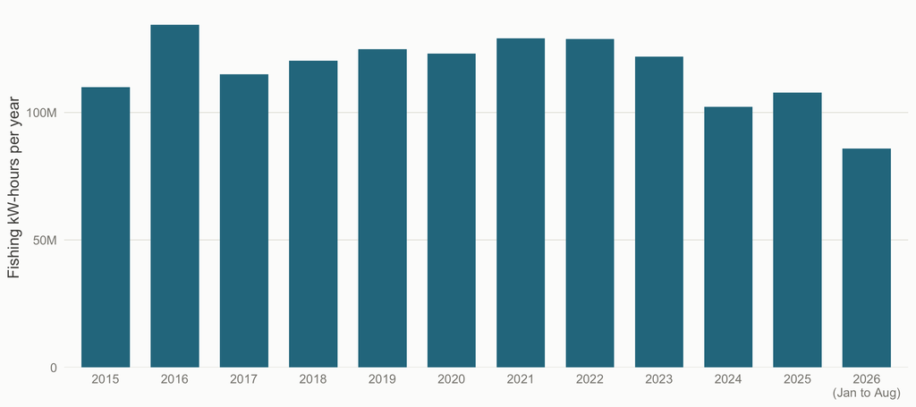

Kilowatt-hours of fishing activity per year. 2026 covers January to August only.

```r
yearly_fishing <- fishing_yearly |>
  dplyr::group_by(year) |>
  dplyr::summarise(kw_hours = sum(kw_hours), .groups = "drop") |>
  dplyr::mutate(
    year_label = dplyr::if_else(year == max(year), paste0(year, "\n(Jan to Aug)"), as.character(year))
  )

ggplot2::ggplot(yearly_fishing, ggplot2::aes(x = year_label, y = kw_hours)) +
  ggplot2::geom_col(fill = data_colour, width = 0.7) +
  ggplot2::scale_y_continuous(
    labels = short_number,
    expand = ggplot2::expansion(mult = c(0, 0.05))
  ) +
  ggplot2::labs(x = NULL, y = "Fishing kW-hours per year") +
  theme_site() +
  ggplot2::theme(panel.grid.major.x = ggplot2::element_blank())
```

# Working with the data

## Files you can start with

Everything here is in the repo’s [data/](https://github.com/emlab-ucsb/mesm-gp-ne-pacific-high-seas-mpa/tree/main/data) folder, so you can read it straight into R, no BigQuery needed. **I’d start with the 2025 file: it’s our main cost layer**, with all vessel activity at 0.05° for 2025, the most recent full year. The [data README](https://github.com/emlab-ucsb/mesm-gp-ne-pacific-high-seas-mpa/blob/main/data/README.md) describes every column of every file, and `readr::read_csv()` reads the `.csv.gz` files just as they are.

```r
starter_files <- tibble::tribble(
  ~file, ~contents, ~data,
  "ais_effort_by_pixel_0p05deg_2025.csv.gz",
  "The main cost layer: all activity at 0.05°, summed over 2025, by vessel class, fishing vessel and fishing activity. The one to start with.",
  cost_layer,
  "ais_effort_by_pixel_0p05deg_all_years.csv.gz",
  "The same, summed over the whole period (January 2015 to August 2026).",
  all_years,
  "ais_fishing_activity_by_pixel_0p05deg_yearly.csv.gz",
  "Fishing activity at 0.05°, by year and vessel class.",
  fishing_yearly,
  "ais_effort_by_pixel_summary.csv",
  "Monthly totals for the whole box, by vessel class, fishing vessel and fishing activity (no pixels).",
  monthly,
  "ais_vessel_class_summary.csv",
  "Number of vessels in each class, and how many the filters dropped.",
  vessel_classes
)

starter_files |>
  dplyr::mutate(
    File = paste0("[`", file, "`](", repo_url, "/blob/main/data/", file, ")"),
    Rows = scales::label_comma()(vapply(data, nrow, integer(1))),
    Size = scales::label_bytes(units = "auto_si", accuracy = 0.1)(file.size(file.path(data_dir, file)))
  ) |>
  dplyr::select(File, `What's in it` = contents, Rows, Size) |>
  knitr::kable(align = c("l", "l", "r", "r"))
```

| File | What’s in it | Rows | Size |
| --- | --- | --- | --- |
| [`ais_effort_by_pixel_0p05deg_2025.csv.gz`](https://github.com/emlab-ucsb/mesm-gp-ne-pacific-high-seas-mpa/blob/main/data/ais_effort_by_pixel_0p05deg_2025.csv.gz) | The main cost layer: all activity at 0.05°, summed over 2025, by vessel class, fishing vessel and fishing activity. The one to start with. | 970,563 | 11.9 MB |
| [`ais_effort_by_pixel_0p05deg_all_years.csv.gz`](https://github.com/emlab-ucsb/mesm-gp-ne-pacific-high-seas-mpa/blob/main/data/ais_effort_by_pixel_0p05deg_all_years.csv.gz) | The same, summed over the whole period (January 2015 to August 2026). | 2,009,937 | 24.5 MB |
| [`ais_fishing_activity_by_pixel_0p05deg_yearly.csv.gz`](https://github.com/emlab-ucsb/mesm-gp-ne-pacific-high-seas-mpa/blob/main/data/ais_fishing_activity_by_pixel_0p05deg_yearly.csv.gz) | Fishing activity at 0.05°, by year and vessel class. | 339,860 | 4.1 MB |
| [`ais_effort_by_pixel_summary.csv`](https://github.com/emlab-ucsb/mesm-gp-ne-pacific-high-seas-mpa/blob/main/data/ais_effort_by_pixel_summary.csv) | Monthly totals for the whole box, by vessel class, fishing vessel and fishing activity (no pixels). | 4,009 | 231.5 kB |
| [`ais_vessel_class_summary.csv`](https://github.com/emlab-ucsb/mesm-gp-ne-pacific-high-seas-mpa/blob/main/data/ais_vessel_class_summary.csv) | Number of vessels in each class, and how many the filters dropped. | 40 | 1.8 kB |

For example, here’s how you could turn 2025’s fishing kW-hours per 0.05° pixel into a raster:

```r
effort <- readr::read_csv("data/ais_effort_by_pixel_0p05deg_2025.csv.gz")

fishing_kw_hours <- effort |>
  dplyr::filter(fishing_activity) |>
  dplyr::group_by(lon_center, lat_center) |>
  dplyr::summarise(kw_hours = sum(kw_hours), .groups = "drop")

# The files store pixel centres, which is what terra wants
fishing_raster <- terra::rast(fishing_kw_hours, type = "xyz", crs = "EPSG:4326")
```

## Bigger datasets

If you need more detail (monthly data, finer pixels, or a particular year), that comes from the full table in emLab’s BigQuery project, and **I’m happy to pull any of it for you.** The table below sizes every option that seemed reasonable, so you can see what each would look like before asking. Every option keeps the vessel class and the two fishing columns.

```r
# How much gzip shrinks these files, measured on the ones in the repo
in_repo <- download_sizes |> dplyr::filter(!is.na(file))
gzip_ratio <- mean(in_repo$csv_mb / (file.size(file.path(data_dir, in_repo$file)) / 1e6))
# Download speed from BigQuery with bigrquery, measured on a 665,000-row cut
rows_per_second <- 40000

format_mb <- function(mb) {
  dplyr::case_when(
    mb >= 1000 ~ paste(scales::label_number(accuracy = 0.1, drop0trailing = TRUE)(mb / 1000), "GB"),
    mb >= 10 ~ paste(scales::label_number(accuracy = 1)(mb), "MB"),
    TRUE ~ paste(scales::label_number(accuracy = 0.1, drop0trailing = TRUE)(pmax(mb, 0.1)), "MB")
  )
}
format_duration <- function(seconds) {
  dplyr::case_when(
    seconds < 60 ~ "under a minute",
    seconds < 3600 ~ paste0("~", round(seconds / 60), " min"),
    TRUE ~ paste0("~", scales::label_number(accuracy = 0.5, drop0trailing = TRUE)(seconds / 3600), " h")
  )
}
time_labels <- c(month = "Monthly", year = "Yearly", all = "Whole period")

download_sizes |>
  dplyr::mutate(
    Activity = dplyr::if_else(fishing_activity_only, "Fishing only", "All"),
    Pixels = paste0(format(pixel_size, nsmall = 2), "°"),
    `Time step` = unname(time_labels[time]),
    Years = dplyr::if_else(is.na(year), "2015 to 2026", as.character(year)),
    Rows = short_number(n_rows),
    CSV = format_mb(csv_mb),
    `Gzipped (approx.)` = format_mb(csv_mb / gzip_ratio),
    `Download (approx.)` = format_duration(n_rows / rows_per_second),
    Where = dplyr::if_else(
      is.na(file),
      "BigQuery",
      paste0("[In the repo](", repo_url, "/blob/main/data/", file, ")")
    )
  ) |>
  # All activity first, then fishing only; within each, the whole window
  # before single years, coarse time steps before fine, coarse pixels first
  dplyr::arrange(Activity == "Fishing only", !is.na(year), time != "all", time != "year", dplyr::desc(pixel_size)) |>
  dplyr::select(Activity, Pixels, `Time step`, Years, Rows, CSV, `Gzipped (approx.)`, `Download (approx.)`, Where) |>
  knitr::kable(align = c("l", "l", "l", "l", "r", "r", "r", "r", "l"))
```

| Activity | Pixels | Time step | Years | Rows | CSV | Gzipped (approx.) | Download (approx.) | Where |
| --- | --- | --- | --- | --- | --- | --- | --- | --- |
| All | 0.10° | Whole period | 2015 to 2026 | 665K | 36 MB | 7.6 MB | under a minute | BigQuery |
| All | 0.05° | Whole period | 2015 to 2026 | 2M | 113 MB | 24 MB | under a minute | [In the repo](https://github.com/emlab-ucsb/mesm-gp-ne-pacific-high-seas-mpa/blob/main/data/ais_effort_by_pixel_0p05deg_all_years.csv.gz) |
| All | 0.01° | Whole period | 2015 to 2026 | 24.6M | 1.4 GB | 282 MB | ~10 min | BigQuery |
| All | 0.10° | Yearly | 2015 to 2026 | 3.5M | 204 MB | 43 MB | ~1 min | BigQuery |
| All | 0.05° | Yearly | 2015 to 2026 | 10.3M | 613 MB | 128 MB | ~4 min | BigQuery |
| All | 0.01° | Yearly | 2015 to 2026 | 108M | 6.4 GB | 1.3 GB | ~45 min | BigQuery |
| All | 0.10° | Monthly | 2015 to 2026 | 16.1M | 1 GB | 211 MB | ~7 min | BigQuery |
| All | 0.05° | Monthly | 2015 to 2026 | 42.8M | 2.8 GB | 577 MB | ~18 min | BigQuery |
| All | 0.01° | Monthly | 2015 to 2026 | 262M | 17 GB | 3.6 GB | ~2 h | BigQuery |
| All | 0.10° | Yearly | 2025 | 320K | 18 MB | 3.9 MB | under a minute | BigQuery |
| All | 0.05° | Yearly | 2025 | 971K | 58 MB | 12 MB | under a minute | [In the repo](https://github.com/emlab-ucsb/mesm-gp-ne-pacific-high-seas-mpa/blob/main/data/ais_effort_by_pixel_0p05deg_2025.csv.gz) |
| All | 0.01° | Yearly | 2025 | 11.6M | 684 MB | 143 MB | ~5 min | BigQuery |
| All | 0.10° | Monthly | 2025 | 1.5M | 96 MB | 20 MB | under a minute | BigQuery |
| All | 0.05° | Monthly | 2025 | 4.3M | 275 MB | 57 MB | ~2 min | BigQuery |
| All | 0.01° | Monthly | 2025 | 30.9M | 2 GB | 420 MB | ~13 min | BigQuery |
| Fishing only | 0.10° | Whole period | 2015 to 2026 | 48.2K | 2.6 MB | 0.5 MB | under a minute | BigQuery |
| Fishing only | 0.05° | Whole period | 2015 to 2026 | 123K | 6.9 MB | 1.4 MB | under a minute | BigQuery |
| Fishing only | 0.01° | Whole period | 2015 to 2026 | 974K | 54 MB | 11 MB | under a minute | BigQuery |
| Fishing only | 0.10° | Yearly | 2015 to 2026 | 151K | 8.7 MB | 1.8 MB | under a minute | BigQuery |
| Fishing only | 0.05° | Yearly | 2015 to 2026 | 340K | 20 MB | 4.2 MB | under a minute | [In the repo](https://github.com/emlab-ucsb/mesm-gp-ne-pacific-high-seas-mpa/blob/main/data/ais_fishing_activity_by_pixel_0p05deg_yearly.csv.gz) |
| Fishing only | 0.01° | Yearly | 2015 to 2026 | 2.3M | 136 MB | 28 MB | under a minute | BigQuery |
| Fishing only | 0.10° | Monthly | 2015 to 2026 | 297K | 19 MB | 3.9 MB | under a minute | BigQuery |
| Fishing only | 0.05° | Monthly | 2015 to 2026 | 611K | 40 MB | 8.3 MB | under a minute | BigQuery |
| Fishing only | 0.01° | Monthly | 2015 to 2026 | 3.5M | 229 MB | 48 MB | ~1 min | BigQuery |

A few rules of thumb:

- **The sizes are close to exact.** They’re computed in BigQuery from the real data, and when I downloaded one cut to check, it came out right at the estimate.
- **Anything under about 10 million rows** downloads in a few minutes and is comfortable to work with on a laptop. Past about 50 million rows things get slow, and the full table (262 million rows) is too big for a laptop’s memory.
- **Bigger downloads are much smaller gzipped** (`readr::write_csv("x.csv.gz")`) or as Parquet (`arrow::write_parquet()`). Those are best kept on the shared drive, since GitHub can’t hold files over 50 MB.

## What’s in the full table

The full table is `emlab-gcp.mesm_gp_ne_pacific_high_seas.ais_effort_by_pixel_v20261016` in BigQuery: one row per month, 0.01° pixel, vessel class, fishing vessel or not, and fishing activity or not. The files above have the same columns, just aggregated.

| Column | What it is |
| --- | --- |
| `month` | First day of the month (UTC). |
| `lon_center`, `lat_center` | Centre of the pixel. A 0.01° pixel spans ±0.005° around it. |
| `vessel_class` | The vessel’s type, e.g. `trawlers`, `cargo`, `passenger`, `tug`. |
| `fishing_vessel` | `TRUE` if GFW classifies the vessel as a fishing vessel. This is about *what the vessel is*. |
| `fishing_activity` | `TRUE` for time spent fishing. This is about *what the vessel was doing*. |
| `hours` | Hours of vessel activity. |
| `kw_hours` | Hours × the vessel’s engine power (kW). |

The table only has rows where there was some activity, so a pixel-month with no vessels simply doesn’t appear. You can treat those as zeros.

- **Hours vs kW-hours.** Hours is how much time vessels spent there. kW-hours weights each hour by the vessel’s engine power, so an hour from a big trawler counts for more than an hour from a small troller. Engine power comes from GFW’s model (replaced by registry values where they exist), and every vessel has one.
- **`fishing_vessel` vs `fishing_activity`.** A trawler steaming to port is a fishing vessel that isn’t fishing: `fishing_vessel = TRUE`, `fishing_activity = FALSE`. A cargo ship is never fishing. The pipeline checks every row, so a non-fishing vessel can never have fishing activity. Fishing activity is GFW’s model estimate of when a vessel is fishing, based on how it moves; GFW calls it “apparent fishing”.
- **Vessel classes** come from GFW’s vessel classification model. When it isn’t confident about a fishing vessel’s gear, it falls back to the generic class `fishing`. Where it has a best guess for one of the gears it predicts well (trawlers, drifting longlines, set gillnets, tuna purse seines, squid jiggers), we use that guess instead. There’s a similar catch-all on the non-fishing side, `non_fishing`. If you’re working with vessel types, GFW’s [pipeline 5 release notes](https://docs.google.com/document/d/1wFtKu_6ixCGCfmTk3j6UPbKBgFrQdJ_BtrGiooC0yDQ/edit) are well worth a read: the sections on the new vessel class model (and its Appendix G) explain how types are assigned and when they roll up to the catch-alls.

## How I built it

1. **The vessel list.** GFW’s vessel identity table (one row per vessel, identified by MMSI, the vessel’s AIS ID), using GFW’s “pipeline 5” models for each vessel’s class, whether it’s a fishing vessel, and its engine power. GFW describes these models in its [pipeline 5 release notes](https://docs.google.com/document/d/1wFtKu_6ixCGCfmTk3j6UPbKBgFrQdJ_BtrGiooC0yDQ/edit).
2. **The positions.** Every AIS position in the box from January 2015 to August 2026, on GFW’s “good” track segments only.
3. **Fishing or not.** Each position from a fishing vessel gets GFW’s fishing call (squid jiggers use a night-loitering rule, since they fish at night under lights). Positions from non-fishing vessels are never fishing.
4. **The pixels.** Positions are binned into 0.01° pixels and summed by month, vessel class and the two fishing flags.

**The box** is the rectangle in `data/small_gfw_bbox_mesm/` (lon −160 to −120, lat 39.89 to 61.55), pushed out to whole degrees (lat 39 to 62) so that coarser pixels (0.05°, 0.1°, 0.25°, 0.5°, 1°) are never cut by its edge. If you’d like to trim back to the box exactly as drawn, you can filter on `lat_center`.

**What I left out, and why:**

- **Fishing gear.** Lots of AIS transmitters are on nets and buoys, not vessels.
- **Vessels GFW couldn’t classify,** which have too little AIS activity for the model (about 0.2% of hours).
- **Noisy vessels:** MMSIs GFW saw broadcasting impossible positions, or shared by two vessels at once. A vessel that was ever noisy is dropped from *every* year, so each vessel is in the time series for all of its years or none of them.
- **Anything after August 2026,** where GFW’s vessel identity data currently ends.

## A few things to keep in mind

- **The box isn’t all high seas.** It includes a big chunk of the US and Canadian EEZs, plus the coast and inland waters, so you’ll want to clip to your planning region before using any of it as a cost.
- **It’s worth deciding early what “cost” means for us.** Fishing activity only, fishing kW-hours, or all traffic? They give quite different maps, and non-fishing traffic is hundreds of times bigger in kW-hours. I’m always happy to talk this through.
- **AIS doesn’t see everything.** Not every vessel carries AIS, some turn it off, and reception varies by place and over time, so it’s worth being a little cautious when reading trends from raw totals.
- **Fishing activity is a model estimate,** not observed fishing.
- **Hours and kW-hours add up, but vessel counts don’t.** You can sum `hours` and `kw_hours` across pixels, months and classes however you like. There aren’t vessel counts per pixel, because the same vessel shows up in lots of pixels and months.
- **Coastal pixels include time in port,** which counts as non-fishing activity.

## Getting more data

The full table lives in emLab’s BigQuery project (`emlab-gcp`), which needs an emLab account to query, so **I’m happy to pull whatever you need.** Just let me know which option from the bigger datasets table you’d like, or describe the resolution, time step, years and activity you have in mind, and I’ll get it to you.

For reference, here’s what a request looks like as a query, using fishing activity by year at 0.1° as an example:

```r
sql <- "
SELECT
  EXTRACT(YEAR FROM month) AS year,
  ROUND(FLOOR(lon_center / 0.1) * 0.1 + 0.05, 3) AS lon_center,
  ROUND(FLOOR(lat_center / 0.1) * 0.1 + 0.05, 3) AS lat_center,
  vessel_class,
  SUM(hours) AS hours,
  SUM(kw_hours) AS kw_hours
FROM `emlab-gcp.mesm_gp_ne_pacific_high_seas.ais_effort_by_pixel_v20261016`
WHERE fishing_activity
GROUP BY 1, 2, 3, 4
"

fishing <- bigrquery::bq_project_query("emlab-gcp", sql) |>
  bigrquery::bq_table_download()
```

The `FLOOR(... / 0.1) * 0.1 + 0.05` bit regrids the 0.01° pixels to 0.1°; for 0.05° pixels, swap in 0.05 and 0.025. Because the table stores pixel centres, this is always exact. If you do have BigQuery access, run `bigrquery::bq_auth()` once to log in. A few tips for keeping queries quick and cheap:

- **Filtering on `month`** helps a lot: the table is partitioned by month, so `WHERE month BETWEEN '2025-01-01' AND '2025-12-01'` only reads 2025.
- **Filtering on `fishing_activity`** early helps too, if that’s all you need: the table is clustered on it, and fishing rows are just a percent or two of the table.
- **The BigQuery console is handy for trying queries first.** It shows how much a query will read before you run it. A query over the whole table reads about 13 GB, roughly $0.07.

# Citing the data

If you use or show this data, please cite Global Fishing Watch’s paper, which is GFW’s official citation for its AIS data:

> Kroodsma, D. A., Mayorga, J., Hochberg, T., Miller, N. A., Boerder, K., Ferretti, F., Wilson, A., Bergman, B., White, T. D., Block, B. A., Woods, P., Sullivan, B., Costello, C., & Worm, B. (2018). Tracking the global footprint of fisheries. *Science*, 359(6378), 904–908. https://doi.org/10.1126/science.aao5646

It’s also nice to say where the data came from, for example: “AIS data from Global Fishing Watch (globalfishingwatch.org), pipeline 5, accessed October 2026.” For details on how GFW builds the data, especially how vessel types are assigned, GFW’s [pipeline 5 release notes](https://docs.google.com/document/d/1wFtKu_6ixCGCfmTk3j6UPbKBgFrQdJ_BtrGiooC0yDQ/edit) (September 2026) are the place to look.

# Code, data and use of generative AI

All code is written in R and SQL and is in the [GitHub repository](https://github.com/emlab-ucsb/mesm-gp-ne-pacific-high-seas-mpa), along with how to reproduce the data. The pipeline runs in BigQuery, and every number on this page is computed from its outputs when the page is built. AIS data and models are from [Global Fishing Watch](https://globalfishingwatch.org) (pipeline 5), and the coastlines from [Natural Earth](https://www.naturalearthdata.com); see Citing the data for how to credit them.

Claude (Anthropic), model Opus 5.5, was used as a coding assistant through Claude Code in October 2026. It drafted and edited the R pipeline, the SQL queries, this page and the README. I set the study area, time window and pixel size, chose the vessel filters and classification rules, and reviewed the code. The model is not an author and holds no accountability: I am responsible for all code, analysis, and conclusions here. No data, results, or citations were produced by Claude itself. Commits made with AI assistance carry a `Co-Authored-By: Claude` trailer, so the contribution can be inspected commit by commit.